# Predicción de los resultados de las elecciones generales del 26J

## Meta-análisis de encuestas para las elecciones generales del 26J

**Virgilio Gómez Rubio**

*Departamento de Matemáticas*

*Universidad de Castilla-La Mancha*

*Campus de Albacete*

**IMPORTANTE:** Última actualización `2024-01-22 00:47:05.442333`.

**CAMBIOS:** Se han incluido intervalos de credibilidad en las estimaciones del número de escaños por partido para incluir una medida de incertidumbre en las estimaciones. Se ha actualizado el número de escaños en Valencia (de 15 a 16) y en León (de 5 a 4), aunque no hay cambios sustanciales en el total (Ciudadanos cede un diputado a Podemos).

En [este otro artículo](https://becarioprecario.github.com/posts/elecciones/rstats/2015/12/20/comparativa_predicciones/) hay una comparativa de predicciones y encuestas de las elecciones del 20D.

Se ha matizado qué representaba el intervalo para los escaños, y se ha incluido un intervalo de credibilidad al 95% (que nos da el rango de escaños que tienen una probabilidad del 95% de ocurrir).

## Introducción

En este artículo mostramos una predicción de la distribución de escaños por provincias y nacional para las próximas elecciones generales del 26 de junio de 2016.

## Resultados

Como primera aproximación, la configuración de escaños obtenida al considerar el número de escaños más probable en cada provincia según nuestro modelo es la siguiente:

| partido | escaños | min95 | max95 | ICmin95 | ICmediana | ICmax95 |
| --- | --- | --- | --- | --- | --- | --- |
| PP | 113 | 98 | 132 | 110 | 114 | 119 |
| PSOE | 81 | 63 | 92 | 76 | 80 | 83 |
| UP | 97 | 77 | 103 | 90 | 94 | 97 |
| Cs | 35 | 29 | 53 | 35 | 38 | 42 |
| ERC | 8 | 8 | 9 | 8 | 8 | 9 |
| CDC | 7 | 6 | 7 | 6 | 7 | 7 |
| PNV | 6 | 6 | 6 | 6 | 6 | 6 |
| Bildu | 3 | 2 | 3 | 2 | 3 | 3 |
| CC | 0 | 0 | 1 | 0 | 0 | 0 |

Los valores `min95` y `max95` indican la variabilidad del número de escaños obtenidos. Se han calculado tomando los cuantiles del 0.025 y del 0.975 del número de escaños asignados a cada partido en cada provincia, por lo que estos intervalos son un tanto extremos. Los valores `ICmin95` y `ICmax95` corresponden a un intervalo de credibilidad del 95% calculado con la distribución de escaños proporcionada por el modelo. Este intervalo de credibilidad indica el número de escaños que obtendría un partido con una probabilidad del 95%. Asimismo, `ICmediana` nos da el valor de la mediana de la distribución de escaños, que usamos como estimación puntual.

Los resultados por provincias pueden verse en el siguiente mapa y en la gráfica que aparece más abajo. Aquí hemos representado el reparto de escaños más probable en cada provincia.

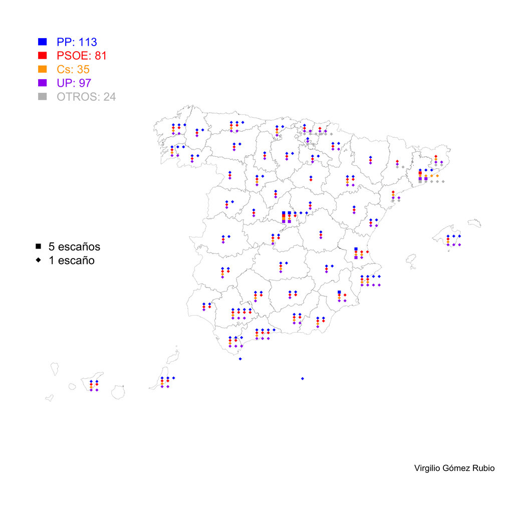

Conviene comentar que hay provincias en las que la distribución de escaños más probable tiene una probabilidad muy pequeña. Por ejemplo, la provincia en la que hay probabilidades más cercanas entre las dos configuraciones de escaños más probables es Málaga, con las siguients configuraciones:

| Cs | OTROSBL | PP | PSOE | UP | Probabilidad |
| --- | --- | --- | --- | --- | --- |
| 1 | 0 | 4 | 3 | 3 | 0.4124 |
| 2 | 0 | 3 | 3 | 3 | 0.4032 |
| 2 | 0 | 4 | 3 | 2 | 0.1818 |
| 1 | 0 | 3 | 4 | 3 | 0.0013 |
| 2 | 0 | 3 | 4 | 2 | 0.0007 |
| 1 | 0 | 4 | 4 | 2 | 0.0005 |
| 2 | 0 | 4 | 2 | 3 | 0.0001 |

## Probabilidades del número de escaños de coaliciones de gobierno

Partiendo de las probabilidades del número de escaños para cada partido podemos calcular las probabilidades de que distintas coaliciones igualen o superen el límte de 176 diputados para formar gobierno. A continuacón mostramos esta probabilidades para UP y PSOE, y PP y Ciudadanos.

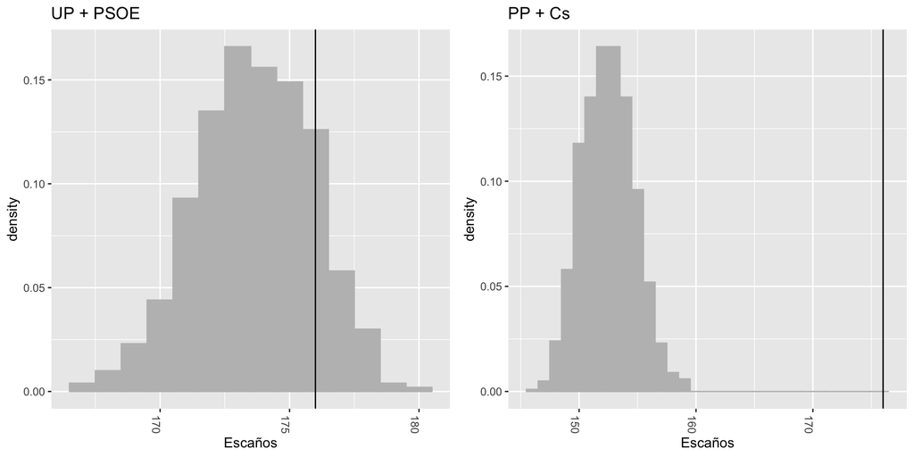

La probabilidad de que UP y Podemos alcance los 176 escaños es de 0.22, mientras que la probabilidad de que PP y Ciudadanos lo consigan es de 0.

## Metodología

Para combinar las distintas encuestas hemos usado un modelo jerárquico Bayesiano que tiene en cuenta las encuestas nacionales, las autonómicas y, en caso de haberlas, las provinciales. El modelo es el mismo usado en las elecciones del 20 de diciembre, con la salvedad de que para arlgunas comunidades autónomas se ha utilizado un modelo que sólo se basa en encuestas regionales y provinciales.

## Referencias

- [Electograph](http://www.electograph.com), como fuente de las encuestas que he usado
- [Diario El País](http://www.elpais.es), como fuente de resultados históricos
- [Artículo de Kiko Llaneras](http://datos.elespanol.com/elecciones-generales/la-cocina-26j/), como artículo relacionado (aunque nuestra metodología es bastante distinta) y que tiene unos gráficos bastante interesantes para mostrar los resultados del análisis

## Apéndice: Resultados por provincias

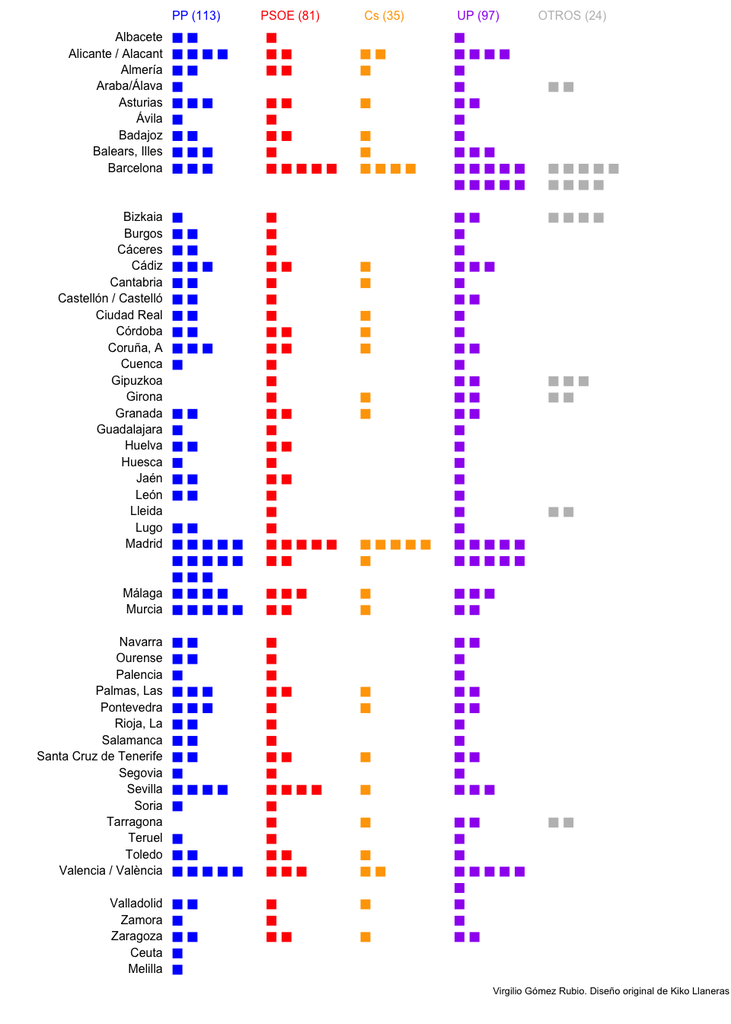